# lecture_sim

Leonardo Feitosa

2024-07-23

# Introduction

The simulation you’ll carry out with the code below refers to an updated version of the traditional fisheries bioeconomic model proposed by Schaefer (1954) and Gordon (1950). This model is based on the continuous logistic population growth model you have learned in class, but now including a harvest term that controls population size - fishing effort. Since we will apply this model to two populations exploited by the same fishery simultaneously, the model consists of a system with three differential equations, simulated over time. The first two model the population size for each species (a target and a bycatch one), and the third models how fishing effort responds to the change in abundance of the two species.

This model consists of three variables: $N_s$ - strong stock population size, $N_w$ - weak stock population size, and $E$ - fishing effort.

We further use 8 parameters:

- $r_i$ = intrinsic population growth rate of species $i$
- $K_i$ = carrying capacity of species $i$
- $q_i$ = catchability coefficient of species $i$ (this denotes the proportion of stock $i$ removed by 1 unit of fishing effort).
- $c$ = cost of fishing (we keep this fixed for ease of analysis).
- $\alpha$ = rate at which effort responses to profits (when $\alpha$ = 1 effort responds instantaneously to changes in profit).
- $A_i$ = rate at which prices respond to changes in catch.
- $\beta_i$ = coefficient of catch flexibility (percent change in catch-per-unit-effort - CPUE - resulting from a 1% change in abundance).
- $f_i$ = coefficient of price flexibility of demand (how much price increases by when supply decreases by 1%).

Don’t worry specifically about what these parameters mean. We’ll only change the values for $r_i$ in this exercise.

## Model equations:

- Strong stock size ($N_s$)

$$\frac{dN_s}{dt} = r_s N_s (1 - \frac{N_s}{K_s}) - q_s N_s^{\beta_s} E$$

- Weak stock size ($N_w$):

$$\frac{dN_w}{dt} = r_w N_w (1 - \frac{N_w}{K_w}) - q_w N_w^{\beta_w} E$$

- Effort ($E$):

$$\frac{dE}{dt} = \alpha E (A_s (q_s N_s^{\beta_s} E)^{-f_s} q_s
N_s^{\beta_s} + A_w (q_w N_w{^\beta_w} E) q_w N_w^{\beta_w} - c)$$

### Setting up the time series simulation

```r
# time steps
times <- seq(1, 200, by = 1)
delta_t <- 1
n = 200

# define general parameters
c <- 0.05       # cost per unit of fishing effort
alpha <- 1      # response rate of effort to profits
A_byc <- 1      # response rate of price to changes in catch
A_tgt <- 1      # response rate of price to changes in catch
q_tgt <- 0.02   # catchability of each stock
q_byc <- 0.02   # catchability of each stock
k_tgt <- 4      # carrying capacity
k_byc <- 2      # carrying capacity
beta_tgt1 <- 1  # catch flexibility coefficient
beta_byc1 <- 0.56  # catch flexibility coefficient
f_tgt1 <- 0     # price flexibility coefficient
f_byc1 <- .22     # price flexibility coefficient

############ YOU ONLY CHANGE THESE ##################
r_tgt <- 1.1      # intrinsic population growth rate
r_byc <-  .1     # intrinsic population growth rate
```

```r
# create place holder vectors
exp.target <- rep(NaN, n)
exp.bycatch <- rep(NaN, n)
exp.effort <- rep(NaN, n)

# setting initial values for each variable
exp.target[1] <- k_tgt
exp.bycatch[1] <- k_byc
exp.effort[1] <- 0.5
```

```r
# run simulation
for(i in 2:length(exp.target)){
    dN_target <- (r_tgt * exp.target[i-1] * (1 - (exp.target[i-1]/k_tgt)) - (q_tgt * exp.target[i-1]^beta_tgt1 * exp.effort[i-1])) * delta_t
    dN_bycatch <- (r_byc * exp.bycatch[i-1] * (1 - (exp.bycatch[i-1]/k_byc)) - (q_byc * exp.bycatch[i-1]^beta_byc1 * exp.effort[i-1])) * delta_t
    d_effort <- (alpha * exp.effort[i-1] *
       (A_tgt * (q_tgt * exp.target[i-1]^beta_tgt1 * exp.effort[i-1])^-f_tgt1 * q_tgt * exp.target[i-1]^beta_tgt1 +
                         A_byc * (q_byc * exp.bycatch[i-1]^beta_byc1 * exp.effort[i-1])^-f_byc1 * q_byc * exp.bycatch[i-1]^beta_byc1 - (c))) * delta_t

    exp.target[i] <- exp.target[i-1] + dN_target
    exp.bycatch[i] <- exp.bycatch[i-1] + dN_bycatch
    exp.effort[i] <- exp.effort[i-1] + d_effort

}

# store results in a tidy data frame
sim_df <- data.frame(target = exp.target,
                    bycatch = exp.bycatch,
                    tgt_div_k = exp.target/k_tgt,   # divides population size per carrying capacity
                    byc_div_k = exp.bycatch/k_byc, # divides population size per carrying capacity
                    effort = exp.effort,
                    time = times,
                    r_tgt = r_tgt,
                    r_byc = r_byc,
                    k_tgt = k_tgt,
                    k_byc = k_byc,
                    q_tgt = q_tgt,
                    q_byc = q_byc) %>%
  pivot_longer(cols = target:bycatch, # tidy absolute abundances for kobe plot
               names_to = "model_vars_abs",
               values_to = "abs_values") %>%
  pivot_longer(cols = tgt_div_k:byc_div_k, # tidy relative abundances for ts plot
               names_to = "model_vars_rel",
               values_to = "b_div_k")
```

```r
# plots population/carrying capacity ratio

pop <-
  ggplot(data = sim_df %>%
           mutate(stocks = ifelse(model_vars_rel == "tgt_div_k", "Target", "Bycatch"))) +
  geom_line(aes(x = time, y = b_div_k, color = stocks),
            linewidth = 1,
            alpha = 0.7) +
  geom_hline(yintercept = 0.5, linetype = "dashed") +
  annotate(geom = "text", label = "Not overfished", x = 160, y = 0.55, size = 4) +
  annotate(geom = "text", label = "Overfished", x = 160, y = 0.45, size = 4) +
  scale_y_continuous(breaks = seq(0, 1, 0.25),
                     limits = c(0, 1)) +
  scale_x_continuous(expand = c(0,0)) +
  labs(x = "Time",
       y = "N/K",
       color = "Species") +
  theme_bw() +
  theme(panel.grid.minor = element_blank(),
        panel.grid.major.x = element_blank())
```

```r
# Plots change in fishing effort over time
effort <-
  ggplot(data = sim_df) +
  geom_line(aes(x = time, y = effort)) +
  labs(x = "Time",
       y = "Fishing Effort",
       color = "Species") +
  scale_x_continuous(expand = c(0,0)) +
  theme_bw() +
  theme(panel.grid.minor = element_blank(),
        panel.grid.major.x = element_blank())
```

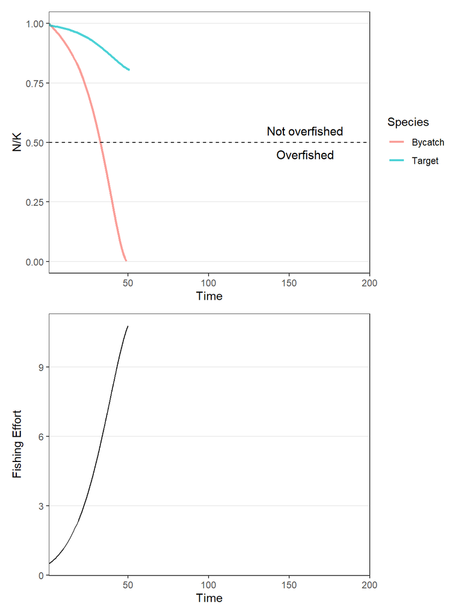

```r
pop / effort
```

**Figure 1.** Changes in strong and weak stock populations as a ratio of their initial biomass and effort over time.

# Let’s plot your stocks on a Kobe plot

```r
# parameters to calculate biomass
weight_tgt = 1
weight_byc = 1

# Get values of points at equilibrium and calculate reference points
sim_df_kobe <- sim_df %>%
  filter(time == 200) %>%
  pivot_wider(names_from = "model_vars_abs",
              values_from = "abs_values")  %>%
  mutate(b_tgt_eq = target * weight_tgt,          # calculates biomass for each stock
         b_byc_eq = bycatch * weight_byc,         # calculates biomass for each stock
         f_tgt_eq = target / b_tgt_eq,            # calculates fishing mortality rate
         f_byc_eq = bycatch / b_byc_eq,           # calculates fishing mortality rate
         msy_tgt = 0.5 * b_tgt_eq * f_tgt_eq,     # calculates MSY for each species
         msy_byc = 0.5 * b_byc_eq * f_byc_eq,     # calculates MSY for each species
         b_msy_tgt = k_tgt * f_tgt_eq,            # calculates Bmsy for each species
         b_msy_byc = k_byc * f_byc_eq,            # calculates Bmsy for each species
         bs_div_bmsy = b_tgt_eq/ b_msy_tgt,       # calculates B/Bmsy for each species
         bw_div_bmsy = b_byc_eq/ b_msy_byc,       # calculates B/Bmsy for each species
         f_msy_tgt = r_tgt / (2 * q_tgt),         # calculates Fmsy for each species
         f_msy_byc = r_byc / (2 * q_byc),         # calculates Fmsy for each species
         fs_div_fmsy = f_tgt_eq / f_msy_tgt,      # calculates F/Fmsy for each species
         fw_div_fmsy = f_byc_eq / f_msy_byc) %>%  # calculates F/Fmsy for each species
  select(model_vars_rel, bs_div_bmsy, bw_div_bmsy, fs_div_fmsy, fw_div_fmsy) %>%
  pivot_longer(cols = c(bs_div_bmsy, bw_div_bmsy, fs_div_fmsy, fw_div_fmsy),
               names_to = c("stock", "ref_point"),
               names_sep = "_div_",
               values_to = "value")

# create subset of reference points for the strong stock
sim_df_kobe_st <- sim_df_kobe %>%
  select(-model_vars_rel) %>%
  filter(str_detect(stock, "s")) %>%
  group_by(ref_point) %>%
  slice_max(n = 2, order_by = value) %>%
  distinct() %>%
  ungroup() %>%
  pivot_wider(names_from = "stock", values_from = "value") %>%
  mutate(stock = "Strong") %>%
  select(-ref_point) %>%
  fill("fs", .direction = "up") %>%
  drop_na(bs)

# create subset of reference points for the weak stock
sim_df_kobe_weak <- sim_df_kobe %>%
  select(-model_vars_rel) %>%
  filter(str_detect(stock, "w")) %>%
  group_by(ref_point) %>%
  slice_max(n = 2, order_by = value) %>%
  distinct() %>%
  ungroup() %>%
  pivot_wider(names_from = "stock", values_from = "value") %>%
  mutate(stock = "Weak") %>%
  select(-ref_point) %>%
  fill("fw", .direction = "up") %>%
  drop_na(bw)
```

[figure not shown]

```r
# Make Kobe plot
ggplot() +
  geom_point(data = sim_df_kobe_st,
             aes(x = bs, y = fs, color = stock),
             size = 4) +
  geom_point(data = sim_df_kobe_weak,
             aes(x = bw, y = fw, color = stock),
             size = 4) +
  geom_hline(yintercept = 1, linetype = "dashed", color = "black", linewidth = 1) +
  geom_vline(xintercept = 1, linetype = "dashed", color = "black", linewidth = 1) +
  scale_x_continuous(breaks = seq(0, 2, 0.5),
                     limits = c(0, 2)) +
  scale_y_continuous(breaks = seq(0, 2, 0.5),
                     limits = c(0, 2)) +
  labs(x = "B/Bmsy", y = "F/Fmsy", color = "Stocks", shape = "Stocks", title = "Kobe plot") +
  theme_bw() +
  theme(panel.grid = element_blank())
```